# CausalCCC step by step

From a raw count matrix to a causal network around ligand–receptor pairs: preprocessing, pitfalls, and how to choose the settings of each function

Author

Minh Le, Jeanne Leclerc

Published

October 14, 2026

## Goal and running example

[CausalCCC](https://miic.curie.fr/causalCCC.php) (Dupuis *et al.*, *NAR* 2025) learns, with the causal network method MIIC, the intracellular genes linked to the ligands of sender cells and to the receptors of receiver cells. This tutorial goes through every step, says what to check at each one, and measures what each setting changes.

### What CausalCCC is: MIIC, a data layout, and forced L-R links

CausalCCC is not a new network method: it is **MIIC run on a specially built table, with the L-R pairs added as forced links**. It has three parts:

| Part | What it does | Where |
| --- | --- | --- |
| **1. Data preparation** | L-R pairs (`causalCCC.links()`, with LIANA), gene selection by mutual information (`causalCCC.MIselection()`), the table (`causalCCC.mosaic()`), the variable types (`causalCCC.state_order()`) | R package `causalCCC` |
| **2. The mosaic table** | sender and receiver cells stacked in one table; sender genes are `NA` in receiver cells and vice versa, so two genes of different cell types are never observed in the same cell | the core idea of the method |
| **3. A modified MIIC** | the L-R pairs are given as `interact_edges`: these links are **forced** (never removed, `skeleton.cpp`) and left out of the search for conditional independences; afterwards each gets the strength of t… | `miic`, branch `causalccc` |

Three consequences for reading a CausalCCC network:

- **The L-R links are imposed, not learnt.** A ligand and its receptor are never measured in the same cells, so MIIC cannot estimate anything between them; their strength is set artificially (notebook `case2/04`, section 6).
- **What MIIC learns are the intracellular networks on each side**: the genes linked to the ligand in the sender cells and to the receptor in the receiver cells. The forced L-R links are the bridge between them.
- **“Upstream” and “downstream” of an L-R pair mean a position relative to that link**, not a causal direction found by MIIC across it (notebook `case2/03`).

The time-consuming parts are the gene selection (part 1) and, above all, the MIIC network reconstruction (part 3); notebook `case2/10` makes both faster without changing their results.

The running example is **case study 2 of the paper**: fibroblasts, T cells and dendritic cells (DCs) from the skin of atopic dermatitis patients (He *et al.* 2020), with 43 ligand–receptor (L-R) pairs from CellChat. We use it because we know the answer: notebooks `case2/03` to `case2/09` rebuilt the authors’ input exactly, so every setting can be scored against the published one.

```
raw counts ─► QC, annotation ─► L-R pairs ─► gene selection (MI) ─► mosaic table + state order ─► MIIC ─► reading
 section 1      sections 2–3      section 4      section 5               sections 6–7                section 8   section 9
```

The package has six functions, all used below; the paper describes none of their settings in detail.

| Function | Role | Section |
| --- | --- | --- |
| `causalCCC.links()` | L-R pairs with LIANA | 4 |
| `causalCCC.MIselection()` | genes sharing the most mutual information (MI) with features of interest | 5 |
| `causalCCC.mosaic()` | the cells × variables table, `NA` outside each cell type’s genes | 6–7 |
| `causalCCC.state_order()` | type (discrete / continuous) and group of each variable | 6–7 |
| `causalCCC.layout()` | drawing layout for the web server (cosmetic) | 6 |
| `causalCCC.wrapper()` | all the above for **one** sender and **one** receiver population | 6 |
| `miic()` (package `miic`, branch `causalccc`) | the causal network | 8 |

**NoteRunning time**

First rendering: about 15 minutes for the gene selection (section 6) and about 50 minutes for the ten MIIC runs (section 8). Every result is saved in `results/tutorial/` and reloaded afterwards; delete a file to recompute it. The full three-population network (section 7) takes 1 to 3 hours and is not run here (command given). Section 8b runs only when a web server job is given (`-P server_job:<link>`): a few minutes for a small network.

## Setup

Three traps before starting:

- **`miic` must be attached before `causalCCC`.** `causalCCC.MIselection()` calls `miic()` without importing it.
- **SeuratObject ≥ 5.3.** `causalCCC.MIselection()` and `causalCCC.mosaic()` read the counts with `GetAssayData(slot = "counts")`, which is now an error (`slot` became `layer`). `patch_causalccc_all()` makes corrected copies of these two functions *and of the wrapper*, so that the wrapper calls the corrected copies. The installed package is not modified.
- **A bug of the wrapper with two or more metadata.** `causalCCC.MIselection()` computes MI with every column of its table, metadata included, so a metadata column (here `labels`, which shares a lot of MI with `condition`) can come back among the selected “genes”. The wrapper then looks for it in the count matrix and stops with `column not found: [labels]`, after the whole MI computation. The patched wrapper removes the metadata from the selected genes. When you call `causalCCC.MIselection()` yourself, do the same (`setdiff(genes, metadata)`).

```r
library(tidyverse)
library(Matrix)
library(Seurat)
library(miic)
library(causalCCC)

root <- getwd()
while (!file.exists(file.path(root, "scripts", "helpers.R"))) {
  if (dirname(root) == root) stop("Repository root not found. Open the repository folder in Positron.")
  root <- dirname(root)
}
source(file.path(root, "scripts", "helpers.R"))                       # select_genes(), link_name(), drawings ...
source(file.path(root, "scripts", "tutorial", "tutorial_helpers.R"))   # functions of this tutorial
source(file.path(root, "scripts", "benchmarks", "compare_outputs.R"))  # compare_miic(), section 8b

patch_causalccc_all()

# Server job to compare with (section 8b): the parameter when rendering, "" when the chunks are run by hand
server_job <- if (exists("params")) params$server_job else ""

job_dir     <- file.path(root, "data", "case2", "causalccc_server_w0788tM1wzXGHLzNaKKa")   # the authors' files
results_dir <- file.path(root, "results", "tutorial")
dir.create(results_dir, recursive = TRUE, showWarnings = FALSE)

cell_types <- c("Fibroblasts", "T_cell", "DCs")
```

# Part 1 – Preparing the data

## 1. CausalCCC needs raw counts

**Why.** `causalCCC.MIselection()` and `causalCCC.mosaic()` read the `counts` layer, and MIIC computes mutual information on these values (it discretises continuous variables itself). Normalised, scaled, SCTransform or integrated values must not be used: they are not what the method was designed for, and log-normalisation introduces a dependence on library size that differs between genes.

Our data is CellChat’s `data_humanSkin`. Is it raw?

```r
load(file.path(root, "data", "case2", "cellchat", "data_humanSkin_CellChat.rda"))
norm <- data_humanSkin$data
meta <- data_humanSkin$meta

dim(norm)
```

```
[1] 17328  7563
```

```r
summary(norm@x)                         # non-zero values
```

```
   Min. 1st Qu.  Median    Mean 3rd Qu.    Max.
 0.3059  1.5676  2.0859  2.1858  2.7000  8.1592
```

```r
all(norm@x == round(norm@x))            # whole numbers?
```

```
[1] FALSE
```

No: the values are log(1 + 10,000 × count / library size). **Check this on any dataset before going further.**

**Recovering counts.** In each cell, the smallest non-zero value is almost surely a count of 1. That gives the library size, then every count. `recover_counts()` does it (method of notebook `case2/05`).

```r
counts <- recover_counts(norm, scale = 1e4)
attr(counts, "max_rounding_error")      # distance to the nearest whole number before rounding
```

```
[1] 3.410605e-12
```

```r
summary(colSums(counts))                # library sizes
```

```
   Min. 1st Qu.  Median    Mean 3rd Qu.    Max.
  103.0   482.5   923.0  1441.5  1839.0 27941.0
```

The values become whole numbers to within rounding noise, so the normalisation is exactly undone. This only works if (1) the scale factor is known (1e4 for Seurat and CellChat, 1e5 in some atlases, for example the thymus atlas of Park *et al.* 2020), (2) all the genes used for the normalisation are still in the matrix, and (3) the values were not scaled, regressed or integrated. Check that the maximum rounding error is tiny; if it is not, the counts cannot be recovered and the raw matrix must be found (GEO, the authors, or re-quantification from FASTQ files).

**TipStarting from a real raw matrix (10x, kallisto|bustools, AnnData)**

The skeleton below (not run) keeps the raw counts untouched while normalising only for clustering and annotation.

```r
# 10x / kallisto|bustools output
raw <- Read10X("path/to/filtered_feature_bc_matrix")
so  <- CreateSeuratObject(raw, min.cells = 3, min.features = 200)
# ... QC (section 2), doublets, then:
so <- NormalizeData(so) |> FindVariableFeatures() |> ScaleData() |> RunPCA()   # for clustering only
# After IntegrateLayers() (Seurat 5), counts are split into one layer per sample: join them before CausalCCC,
# otherwise GetAssayData(layer = "counts") does not return all cells.
so <- JoinLayers(so)
# AnnData from scanpy: keep adata.layers["counts"] = adata.X.copy() BEFORE normalize_total(), and export that layer.
```

**Gene names.** CausalCCC matches L-R genes to the row names of the count matrix by exact name, and drops silently those it does not find (section 4). Check for duplicated names, `make.unique()` suffixes (`.1`), and that the matrix and the L-R resource use the same annotation: in case study 1, four genes had been renamed between annotations (for example Gnb2l1 → Rack1), and our kallisto run of case study 2 had ATP5F1E instead of ATP5E.

```r
c(genes = nrow(counts),
  duplicated_names = sum(duplicated(rownames(counts))),
  make_unique_suffix = sum(str_detect(rownames(counts), "\\.[0-9]+$")))
```

```
             genes   duplicated_names make_unique_suffix
             17328                  0                  7
```

```r
str_subset(rownames(counts), "\\.[0-9]+$")
```

```
[1] "CH17-340M24.3" "CTC-338M12.4"  "CTD-2201I18.1" "GS1-124K5.11"
[5] "GS1-259H13.2"  "CTD-3080P12.3" "CTB-178M22.2"
```

Names ending in `.1`, `.2`… are either genuine names or the trace of `make.unique()` applied to duplicated symbols, in which case two genes shared one symbol upstream. Here all seven are genuine clone-based lncRNA names (such as CTD-2201I18.1), and none is an L-R gene.

## 2. Quality control on raw counts

CausalCCC has no QC of its own: every cell of the selected types enters the network. Cells that are empty droplets, doublets or damaged add spurious dependencies (a doublet expresses the genes of two cell types).

```r
meta$cell_type <- recode(as.character(meta$labels),
  "APOE+ FIB" = "Fibroblasts", "FBN1+ FIB" = "Fibroblasts", "COL11A1+ FIB" = "Fibroblasts", "Inflam. FIB" = "Fibroblasts",
  "TC" = "T_cell", "Inflam. TC" = "T_cell", "CD40LG+ TC" = "T_cell", "NKT" = "T_cell",
  "cDC1" = "DCs", "cDC2" = "DCs", "LC" = "DCs", "Inflam. DC" = "DCs")
meta$labels <- as.character(meta$labels)

so <- CreateSeuratObject(counts = counts, meta.data = meta)

# Are the mitochondrial and ribosomal genes in the matrix?
c(mitochondrial_genes = sum(str_detect(rownames(so), "^MT-")), ribosomal_genes = sum(str_detect(rownames(so), "^RP[SL]")))
```

```
mitochondrial_genes     ribosomal_genes
                  0                   0
```

```r
so@meta.data |>
  group_by(cell_type) |>
  summarise(cells = n(),
            median_counts = median(nCount_RNA), min_counts = min(nCount_RNA),
            median_genes = median(nFeature_RNA), min_genes = min(nFeature_RNA), max_genes = max(nFeature_RNA)) |>
  knitr::kable(digits = 1)
```

| cell_type | cells | median_counts | min_counts | median_genes | min_genes | max_genes |
| --- | --- | --- | --- | --- | --- | --- |
| DCs | 629 | 3015.0 | 185 | 1299.0 | 150 | 4523 |
| Fibroblasts | 4734 | 953.5 | 103 | 645.5 | 99 | 4238 |
| T_cell | 2200 | 698.0 | 104 | 493.0 | 98 | 2924 |

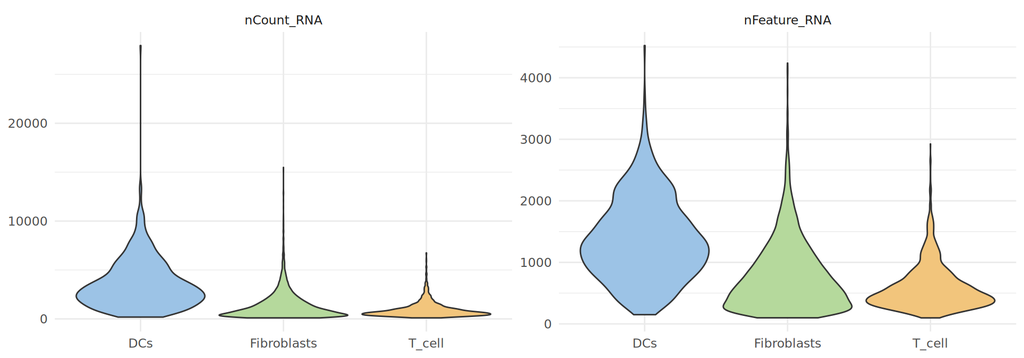

```r
so@meta.data |>
  select(cell_type, nCount_RNA, nFeature_RNA) |>
  pivot_longer(-cell_type) |>
  ggplot(aes(cell_type, value, fill = cell_type)) +
  geom_violin(scale = "width", show.legend = FALSE) +
  scale_fill_manual(values = cell_type_colours) +
  facet_wrap(~name, scales = "free_y") +
  labs(x = NULL, y = NULL) +
  theme_minimal()
```

**The matrix has no mitochondrial and no ribosomal genes**: they were removed before CellChat normalised the data, so the library sizes recovered in section 1 exclude them. The mitochondrial filter cannot be checked on this dataset, and a `PercentageFeatureSet(pattern = "^MT-")` of 0 would mean missing genes, not healthy cells. Check that these genes are present before computing QC metrics.

This dataset was already filtered by its authors, so we only look. On a new dataset, typical filters are:

| Filter | Typical threshold | Our kallisto run of case study 2 | Comment |
| --- | --- | --- | --- |
| genes per cell | > 200 (empty droplets) | 200 < genes < 6,000 | Park 2020: > 500 genes and > 2,000 counts |
| upper bound on genes or counts | > 6,000–7,000 genes removed | 6,000 | a crude doublet filter |
| mitochondrial % | < 5–20 %, tissue dependent | < 15 % (skin) | dissociated tissues tolerate more |
| doublets | Scrublet (Python) or scDblFinder (R), per sample | Scrublet | not installed here, so not run |
| genes | detected in ≥ 3 cells | 3 |  |

Set the thresholds **per cell type** when the types differ a lot in size (DCs have about four times the counts of T cells here), and filter **before** recovering or storing the counts layer that CausalCCC will read.

**Detection of the L-R genes.** MI needs variation: a gene detected in a handful of cells carries almost no information, and its links will rest on few cells. Check the fraction of cells expressing each ligand and receptor in its own cell type.

```r
lr_pairs <- read_tsv(file.path(job_dir, "clean_interact_edges.tsv"),
                     col_names = c("ligand", "receptor"), show_col_types = FALSE)
split_var <- function(v) tibble(variable = v, gene = str_remove(v, "_(Fibroblasts|T_cell|DCs)$"),
                                cell_type = str_extract(v, "(Fibroblasts|T_cell|DCs)$"))
lr_roles <- bind_rows(split_var(lr_pairs$ligand) |> mutate(role = "ligand"),
                      split_var(lr_pairs$receptor) |> mutate(role = "receptor")) |>
  distinct()

detection <- lr_roles |>
  mutate(detected_in = map2_dbl(gene, cell_type, \(g, t) mean(counts[g, meta$cell_type == t] > 0))) |>
  arrange(detected_in)
detection |> mutate(detected_in = scales::percent(detected_in, 1)) |> head(10)
```

```
# A tibble: 10 × 5
   variable             gene     cell_type   role     detected_in
   <chr>                <chr>    <chr>       <chr>    <chr>
 1 CCL19_Fibroblasts    CCL19    Fibroblasts ligand   6%
 2 CD74_Fibroblasts     CD74     Fibroblasts receptor 8%
 3 CCR7_DCs             CCR7     DCs         receptor 13%
 4 IGFBP3_Fibroblasts   IGFBP3   Fibroblasts ligand   14%
 5 IL13_T_cell          IL13     T_cell      ligand   15%
 6 ACKR3_Fibroblasts    ACKR3    Fibroblasts receptor 15%
 7 P4HB_T_cell          P4HB     T_cell      receptor 18%
 8 BSG_T_cell           BSG      T_cell      receptor 19%
 9 TNFSF14_T_cell       TNFSF14  T_cell      ligand   19%
10 TNFRSF1A_Fibroblasts TNFRSF1A Fibroblasts receptor 22%
```

2 of the 44 L-R genes are detected in fewer than 10 % of the cells of their type (for example CCL19 in fibroblasts). They are kept because the L-R pair needs them, but links around them deserve caution. In fibroblasts, CCL19 is detected in 283 cells.

**Ribosomal and mitochondrial genes.** They are highly expressed in every cell and follow library size, so they share MI with almost any gene and invade the selection. In case study 1 the default selection contained 33 ribosomal genes, none of which the authors kept (notebook `case1/03`); removing them before the selection was needed to reproduce the authors’ input (notebook `case1/04`). This dataset has none, so the question does not arise here. On your data, count them among the best-ranked genes of the MI tables (section 5) and decide **before** the selection.

## 3. Populations and metadata

`interact_ident` is the metadata column that names the populations; senders and receivers are levels of it. Two properties of the populations matter.

**Size.** MIIC needs enough cells to detect dependencies: with few cells, only strong links survive. The paper’s smallest population has 151 cells (case study 3). Here:

```r
table(meta$cell_type, meta$condition)
```

```
                LS   NL
  DCs          563   66
  Fibroblasts 2706 2028
  T_cell      1742  458
```

**Confounders.** Cells were pooled across conditions (LS = lesional, NL = non-lesional) and subtypes. Genes that differ between conditions or subtypes are then dependent through them; giving the condition and the subtype to MIIC as **metadata variables** lets it explain those dependencies instead of linking genes directly. The DCs are 90 % lesional, so in DCs the condition is nearly constant and carries little information; this also means DC links mostly describe lesional skin. When a metadata column is almost confounded with the cell type (for example the developmental stages of the thymus atlas), it cannot be separated from it.

**Library size.** Raw counts of most genes increase with the number of counts of the cell. That shared factor creates dependencies between genes that are not regulation. MIIC does not correct for it. We measure it on the genes the authors selected for DCs:

```r
authors_mosaic <- read_tsv(file.path(job_dir, "input.tsv"), guess_max = Inf, show_col_types = FALSE)
row_type <- case_when(!is.na(authors_mosaic$labels_Fibroblasts) ~ "Fibroblasts",
                      !is.na(authors_mosaic$labels_T_cell)      ~ "T_cell",
                      !is.na(authors_mosaic$labels_DCs)         ~ "DCs")
col_type <- column_cell_type(authors_mosaic, row_type)
strip    <- function(v) str_remove_all(v, "_(Fibroblasts|T_cell|DCs)")

# The authors' genes of each cell type (without metadata, suffixes and duplicated copies)
authors_genes <- map(set_names(cell_types), \(t) {
  unique(strip(names(authors_mosaic)[col_type == t & !str_detect(names(authors_mosaic), "^(labels|condition)_")]))
})

dc_cells <- which(meta$cell_type == "DCs")
cor_with_depth <- map_dbl(authors_genes$DCs, \(g) cor(counts[g, dc_cells], so$nCount_RNA[dc_cells], method = "spearman"))
summary(cor_with_depth)
```

```
    Min.  1st Qu.   Median     Mean  3rd Qu.     Max.
-0.02677  0.45924  0.72060  0.62481  0.80814  0.89826
```

Most selected genes correlate positively with library size (median Spearman correlation 0.72). The published analyses do not correct for it. A possible safeguard, not used by the authors, is to add a discretised library size (for example its tertiles) as a metadata variable, so that MIIC can use it as a common cause.

## 4. Ligand–receptor pairs

CausalCCC does not infer communication itself: it takes L-R pairs as given. Two options:

1. **`causalCCC.links()`**, which calls LIANA on the Seurat object (not run here, because the case study used CellChat):

```r
causalCCC.links(so, species = "human", assay_name = "RNA", interact_ident = "cell_type",
                senders = "Fibroblasts", receivers = "DCs",
                CCC_method = "cellphonedb",  # or connectome, logfc, natmi, sca
                n_CCClinks = 30)             # pairs kept, ranked by the method's score
```

| Argument | Effect | Advice |
| --- | --- | --- |
| `CCC_method` | ranking score: `lr.mean` (cellphonedb), `prod_weight` (natmi), `LRscore` (sca), `weight_sc` (connectome), `logfc_comb` (logfc) | only cellphonedb and natmi also filter on p ≤ 0.05; the other three keep the top pairs whatever their significance |
| `n_CCClinks` | number of pairs kept (default 30 here, **20** when called through the wrapper) | each extra ligand or receptor adds MI computations (about one minute each) and genes to the network |
| `species` | `"mouse"` converts the resource to mouse orthologues | failed inside OmnipathR for case study 1 (mouse); give the pairs yourself then |

2. **Your own pairs** (CellChat, CellPhoneDB, NicheNet…), as a data frame with columns `ligands` and `receptors`.

Checks before using them:

- **Gene names.** The wrapper keeps only the ligands and receptors found in the row names of the count matrix, without a warning. Complexes must be split into their subunits (the wrapper does it for LIANA receptors, separated by `_`, but not for ligands).
- **One table per direction.** The wrapper handles one sender and one receiver. Here the 43 pairs span six directions:

```r
directions <- lr_pairs |>
  transmute(sender = str_extract(ligand, "(Fibroblasts|T_cell|DCs)$"),
            receiver = str_extract(receptor, "(Fibroblasts|T_cell|DCs)$"),
            ligand = strip(ligand), receptor = strip(receptor))

directions |>
  group_by(sender, receiver) |>
  summarise(pairs = n(), ligands = n_distinct(ligand), receptors = n_distinct(receptor),
            receptor_order = paste(unique(receptor), collapse = " "), .groups = "drop")
```

```
# A tibble: 6 × 6
  sender      receiver    pairs ligands receptors receptor_order
  <chr>       <chr>       <int>   <int>     <int> <chr>
1 DCs         Fibroblasts     6       5         6 ACKR3 BSG CD44 TNFRSF1A P4HB …
2 DCs         T_cell          7       3         6 CD74 CD44 CXCR4 BSG PTPRC P4HB
3 Fibroblasts DCs            11       7        10 CD74 CD44 CXCR4 FPR3 ITGAX IT…
4 Fibroblasts T_cell          5       3         4 CD74 CD44 CXCR4 BSG
5 T_cell      DCs             9       6         9 CD74 CD44 CXCR4 FPR3 BSG IL13…
6 T_cell      Fibroblasts     5       3         5 CD74 CD44 ACKR3 BSG TNFRSF1A
```

```r
# Every L-R gene is in the matrix
all(c(directions$ligand, directions$receptor) %in% rownames(counts))
```

```
[1] TRUE
```

Note the **order** of the receptors: the wrapper uses only the first 8 ligands and the first 8 receptors of a direction as features of interest (section 5). Fibroblasts → DCs and T cells → DCs have more than 8 receptors.

# Part 2 – Choosing the genes

## 5. Gene selection: `causalCCC.MIselection()`

### What it computes

For one population (`oneinteract`), with a list of **features of interest** (`goi`, the ligands or receptors, plus the metadata of `metadata_list`):

1. MI between each feature of interest and **every gene** of the matrix, computed by `miic()` without orientation, in blocks of 100 genes (the `info_shifted` value of each pair). A variable with 5 or fewer distinct values is treated as discrete. At most 30 features of interest. `n_threads = 8` is fixed inside the function.
2. The **3 genes with the highest MI with each feature of interest**.
3. The **`n_genes` genes with the highest MI with any feature of interest**. Default: `max(15, min(4 × length(goi), 100))`.
4. Only genes with MI above `bit_thresold` (sic, default 0.001).

Step 1 takes about a minute per feature of interest; steps 2–4 are instant. So the efficient way to explore settings is to compute the MI table once (`return_full = TRUE`, or `save = TRUE` which writes `<population>_MI_table.csv`) and redo steps 2–4, which `select_genes()` (in `scripts/helpers.R`) reproduces line by line.

To compute the MI table itself, `compute_mi_table()` (`scripts/helpers.R`) gives exactly the table of `causalCCC.MIselection(return_full = TRUE)`, about 20 % faster and with a third of the memory: it keeps the counts sparse and skips genes never detected in the population (notebook `case2/10`). Keep its blocks at about 100 genes (`block_size`, the package’s value): larger blocks are slower.

One subtlety: the MI table contains a row for **every column** of the population’s table, metadata included. The MI tables reused here were computed with both metadata, so `labels` is a candidate “gene” in them; in a call with `condition` only, it is not. We check `select_genes()` on one small call, removing `labels` from the candidates to match it:

```r
# MI tables of every gene with every ligand, receptor and metadata of each cell type (notebook case2/05, 30 minutes)
mi_tables <- readRDS(file.path(root, "results", "case2", "05_rebuild_input", "mi_tables.rds"))

check_file <- file.path(results_dir, "miselection_check.rds")
if (!file.exists(check_file)) {
  invisible(capture.output(suppressMessages(
    package_genes <- causalCCC.MIselection(so, assay_name = "RNA", interact_ident = "cell_type", oneinteract = "DCs",
                                           goi = "CXCR4", metadata_list = "condition"))))
  saveRDS(package_genes, check_file)
}
package_genes <- readRDS(check_file)

our_genes <- select_genes(filter(mi_tables, cell_type == "DCs", variables != "labels"), foi = c("CXCR4", "condition"),
                          n_genes = default_n_genes("CXCR4"))
identical(package_genes, our_genes)
```

```
[1] TRUE
```

```r
package_genes
```

```
 [1] "RGS1"     "NR4A3"    "GPR183"   "HLA-DQA2" "EIF2AK4"  "CAMSAP2"
 [7] "CD83"     "BTG1"     "EIF1"     "UBC"      "PTGER4"   "DUSP4"
[13] "ID2"      "SAT1"     "SRGN"     "HERPUD1"  "REL"      "CDKN1A"
```

```r
# With labels left among the candidates, it is selected as if it were a gene
setdiff(select_genes(filter(mi_tables, cell_type == "DCs"), foi = c("CXCR4", "condition"), n_genes = 15), package_genes)
```

```
[1] "labels"
```

This is the origin of the wrapper bug patched in the Setup: a metadata column selected as a gene. Always remove the metadata from the selected genes (`setdiff(genes, metadata)`).

### How many genes? (`n_genes`)

The MI of the best genes falls quickly, then flattens. The curve of each feature of interest shows where the informative genes end:

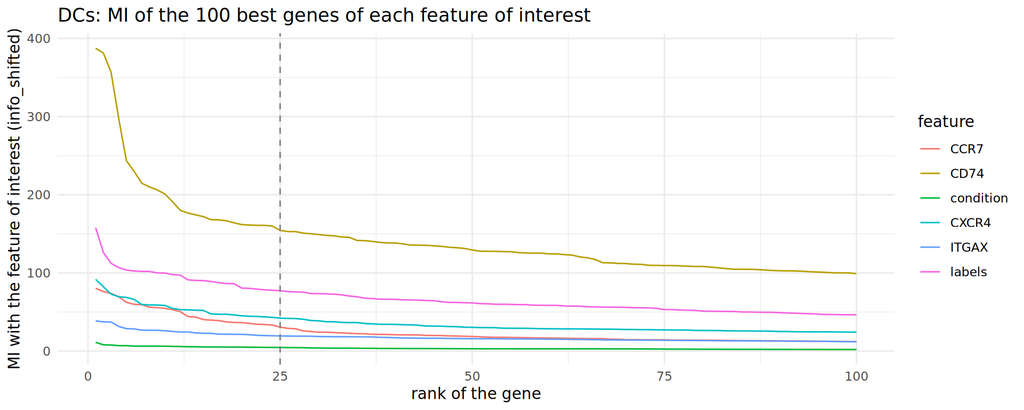

```r
mi_tables |>
  filter(cell_type == "DCs", foi %in% c("CXCR4", "CD74", "CCR7", "ITGAX", "labels", "condition")) |>
  group_by(foi) |>
  slice_max(value, n = 100, with_ties = FALSE) |>
  mutate(rank = row_number()) |>
  ggplot(aes(rank, value, colour = foi)) +
  geom_line() +
  geom_vline(xintercept = 25, linetype = "dashed", colour = "grey50") +
  labs(x = "rank of the gene", y = "MI with the feature of interest (info_shifted)", colour = "feature",
       title = "DCs: MI of the 100 best genes of each feature of interest") +
  theme_minimal()
```

The subtype `labels` shares more MI with genes than most ligands and receptors (it ranks 3rd or 4th in each cell type, behind highly expressed genes such as CD74, MIF or PPIA): as a feature of interest, it pulls in subtype markers. `condition` shares little MI with any gene (it ranks near the bottom in each cell type). The selection takes the top `n_genes` by their **highest** MI over all features, so it is dominated by the features with the largest MI.

### Scoring the settings

We now vary one setting at a time, in the protocol that reproduces the authors’ input exactly (notebook `case2/07`): one selection per sender → receiver direction, pooled per cell type. Each setting is scored against the authors’ selected genes (L-R genes excluded, since they are always kept): `missing` = authors’ genes not selected, `extra` = genes selected but not used by the authors.

```r
lr_genes  <- map(set_names(cell_types), \(t) lr_roles$gene[lr_roles$cell_type == t])
both_meta <- c("labels", "condition")
fixed     <- function(n) \(goi) n

settings <- tribble(
  ~setting,                                ~meta_s,     ~meta_r,     ~cap, ~n_genes,            ~drop,
  "exact (authors): 25 genes, no cap, both metadata", both_meta, both_meta, Inf, list(fixed(25)), NA,
  "n_genes = 15",                          both_meta,   both_meta,   Inf,  list(fixed(15)),     NA,
  "n_genes = 50",                          both_meta,   both_meta,   Inf,  list(fixed(50)),     NA,
  "n_genes = 100",                         both_meta,   both_meta,   Inf,  list(fixed(100)),    NA,
  "n_genes = default formula",             both_meta,   both_meta,   Inf,  list(default_n_genes), NA,
  "cap of 8 (wrapper)",                    both_meta,   both_meta,   8,    list(fixed(25)),     NA,
  "no metadata",                           NULL,        NULL,        Inf,  list(fixed(25)),     NA,
  "labels only",                           "labels",    "labels",    Inf,  list(fixed(25)),     NA,
  "condition only",                        "condition", "condition", Inf,  list(fixed(25)),     NA,
  "ribosomal + mitochondrial removed",     both_meta,   both_meta,   Inf,  list(fixed(25)),     "^(RP[SL]|MT-)",
  "wrapper defaults (cap 8, default n_genes)", both_meta, both_meta, 8,    list(default_n_genes), NA)

selections <- pmap(settings, \(setting, meta_s, meta_r, cap, n_genes, drop) {
  if (!is.function(n_genes)) n_genes <- n_genes[[1]]   # tribble() keeps the function inside a list
  select_by_direction(mi_tables, directions, meta_s, meta_r, cap = cap, n_genes = n_genes,
                      drop = if (is.na(drop)) NULL else drop)
}) |> set_names(settings$setting)

authors_selected <- map(set_names(cell_types), \(t) setdiff(authors_genes[[t]], lr_genes[[t]]))

imap(selections, \(s, name) score_selection(s, authors_selected, lr_genes) |> mutate(setting = name)) |>
  list_rbind() |>
  group_by(setting) |>
  summarise(genes = sum(selected), missing = sum(missing), extra = sum(extra), jaccard = round(mean(jaccard), 2)) |>
  arrange(match(setting, settings$setting)) |>
  knitr::kable()
```

| setting | genes | missing | extra | jaccard |
| --- | --- | --- | --- | --- |
| exact (authors): 25 genes, no cap, both metadata | 174 | 0 | 0 | 1.00 |
| n_genes = 15 | 138 | 36 | 0 | 0.79 |
| n_genes = 50 | 262 | 0 | 88 | 0.66 |
| n_genes = 100 | 452 | 0 | 278 | 0.38 |
| n_genes = default formula | 177 | 8 | 11 | 0.90 |
| cap of 8 (wrapper) | 169 | 5 | 0 | 0.97 |
| no metadata | 154 | 37 | 17 | 0.71 |
| labels only | 170 | 4 | 0 | 0.98 |
| condition only | 159 | 32 | 17 | 0.74 |
| ribosomal + mitochondrial removed | 174 | 0 | 0 | 1.00 |
| wrapper defaults (cap 8, default n_genes) | 167 | 14 | 7 | 0.89 |

**One selection per direction or per cell type?** The alternative is a single selection per cell type with all its ligands and receptors together:

```r
per_cell_type <- map(set_names(cell_types), \(t) {
  goi <- unique(lr_genes[[t]])
  setdiff(select_genes(filter(mi_tables, cell_type == t), foi = c(goi, both_meta), n_genes = 25), both_meta)
})
score_selection(per_cell_type, authors_selected, lr_genes)
```

```
# A tibble: 3 × 6
  cell_type   selected shared missing extra jaccard
  <chr>          <int>  <int>   <int> <int>   <dbl>
1 Fibroblasts       42     42      18     0   0.7
2 T_cell            36     36      15     0   0.706
3 DCs               57     57       6     0   0.905
```

## 6. The wrapper, `causalCCC.wrapper()`, on one direction

The wrapper chains sections 4 and 5 and builds the files for MIIC, for **one sender and one receiver**. Its arguments:

| Argument | Default | What it does | Advice |
| --- | --- | --- | --- |
| `data_input` |  | Seurat object with the raw counts in `assay_name` (the documentation also allows a data frame) | use a Seurat object (`CreateSeuratObject(counts, meta.data = meta)`): the data-frame path is broken, the wrapper looks for the L-R genes in `row.names(data_input)`, which are cell names, so it drops e… |
| `interact_ident`, `senders_name`, `receivers_name` | `NULL` | population column and levels | always give all three (otherwise the first two levels of the active identity are taken) |
| `do_CCC`, `CCC_method`, `n_CCClinks` | `FALSE`, cellphonedb, 20 | run `causalCCC.links()` (section 4); `do_CCC = TRUE` forces `do_MIselect = TRUE` | cellphonedb is used only with `do_CCC = TRUE`; by default no pair is inferred and `interact_edges` must be given (as below) |
| `interact_edges` | `NULL` | data frame with columns `ligands`, `receptors` | required if `do_CCC = FALSE`; order matters (cap of 8) |
| `do_MIselect` | `FALSE` | run the MI selection | otherwise give `genes_senders` and `genes_receivers` |
| `n_genes_senders`, `n_genes_receivers` | `NULL` = default formula | `n_genes` of each selection (≤ 500) | section 5 |
| `goi_senders`, `goi_receivers` | `NULL` | extra features of interest (a transcription factor, a marker…): genes are selected around them as around the ligands / receptors; they are added **before** the first 8 ligands / receptors | each one takes a place among the 8 |
| `metadata_senders`, `metadata_receivers` | `list()` | **named list**: names = metadata columns, values = their levels in increasing order (written to the state order). The metadata are features of interest of the selection (they pull in their markers) an… | a character vector is not accepted by `causalCCC.state_order()` |
| `genes_senders`, `genes_receivers` | `NULL` | genes added to the selection, or the full lists if `do_MIselect = FALSE` |  |
| `save`, `plot` | `TRUE` | MI tables and heatmaps in `wd_path/MI_tables/` | keep `save = TRUE`: the tables let you redo the selection with other settings in seconds |
| `do_layout`, `wd_path` | `FALSE`, working dir | layout for the web server; output folder `CausalCCC_files/` |  |

Hidden behaviours to know: the cap of 8; with two metadata or more it stops after the MI computation unless patched (see Setup); ligands and receptors missing from the matrix are dropped silently; a gene selected in both the sender and the receiver population of the run (for example B2M in fibroblasts and in DCs) is written as two columns, `B2M_senders` and `B2M_receivers`, while a gene selected on one side only keeps its plain name; metadata given on both sides are suffixed the same way; cells are shuffled with `sample()`, so set a seed.

We run it on fibroblasts → DCs, the direction of CXCL12–CXCR4 (Figure 3 of the paper), with the default settings and both metadata.

```r
pairs_fib_dc <- directions |> filter(sender == "Fibroblasts", receiver == "DCs") |>
  transmute(ligands = ligand, receptors = receptor) |> as.data.frame()
levels_of <- function(t) list(labels = sort(unique(meta$labels[meta$cell_type == t])), condition = c("NL", "LS"))

wrapper_dir  <- file.path(results_dir, "wrapper_fibroblasts_dcs")
wrapper_file <- file.path(wrapper_dir, "wrapper_output.rds")
if (!file.exists(wrapper_file)) {
  dir.create(wrapper_dir, showWarnings = FALSE)
  set.seed(2026)
  invisible(capture.output(suppressMessages(
    wrapper_out <- causalCCC.wrapper(so, assay_name = "RNA", interact_ident = "cell_type",
                                     senders_name = "Fibroblasts", receivers_name = "DCs",
                                     interact_edges = pairs_fib_dc, do_MIselect = TRUE,
                                     metadata_senders = levels_of("Fibroblasts"),
                                     metadata_receivers = levels_of("DCs"),
                                     save = TRUE, plot = TRUE, wd_path = wrapper_dir))))
  saveRDS(wrapper_out, wrapper_file)
}
wrapper_out <- readRDS(wrapper_file)

dim(wrapper_out$mosaic_table)
```

```
[1] 5363  111
```

```r
count(wrapper_out$state_order, group, var_type)
```

```
            group var_type  n
1         ligands        1  7
2        metadata        0  4
3 receivers genes        1 48
4       receptors        1 10
5   senders genes        1 42
```

What the cap of 8 did: the receptors used as features of interest are those of the MI table of DCs.

```r
wrapper_mi <- map(c(Fibroblasts = "Fibroblasts", DCs = "DCs"), \(t)
  read_tsv(file.path(wrapper_dir, "MI_tables", paste0(t, "_MI_table.csv")), show_col_types = FALSE))
list(receptors_of_the_direction = unique(pairs_fib_dc$receptors),
     receptors_used_for_selection = intersect(unique(pairs_fib_dc$receptors), unique(wrapper_mi$DCs$foi)))
```

```
$receptors_of_the_direction
 [1] "CD74"    "CD44"    "CXCR4"   "FPR3"    "ITGAX"   "ITGB2"   "CCR7"
 [8] "ITGAM"   "BSG"     "TMEM219"

$receptors_used_for_selection
[1] "CD74"  "CD44"  "CXCR4" "FPR3"  "ITGAX" "ITGB2" "CCR7"  "ITGAM"
```

BSG and TMEM219 (the 9th and 10th receptors) are in the network, but no gene was selected for them.

```r
knitr::include_graphics(file.path(wrapper_dir, "MI_tables", "DCs_MI_heatmap_filtered.png"))
```

[figure not shown]

How to read it. Rows: the features of interest of DCs (the receptors kept by the cap of 8, plus `labels` and `condition`). Columns: the genes selected for DCs. Colour: MI between the feature and the gene across DC cells (miic’s `info_shifted`, which grows with the number of cells: compare colours within one figure, not across datasets). CD74 dominates, through the MHC-II genes (HLA-DRA, HLA-DPB1, HLA-DQB1); CCR7, ITGAX and ITGAM bring almost no genes of their own, and `condition` shares almost no MI with any gene. `labels` appears as a column: this is the metadata selected as a gene, which the patched wrapper then removes.

Suffixes and the variable names of the output:

```r
str_subset(names(wrapper_out$mosaic_table), "_(senders|receivers)$")
```

```
 [1] "LGALS1_senders"      "TMSB10_senders"      "S100A6_senders"
 [4] "S100A10_senders"     "ANXA2_senders"       "TMSB4X_senders"
 [7] "VIM_senders"         "S100A4_senders"      "FTH1_senders"
[10] "ACTB_senders"        "ACTG1_senders"       "SERF2_senders"
[13] "B2M_senders"         "SH3BGRL3_senders"    "TPT1_senders"
[16] "CST3_senders"        "labels_senders"      "condition_senders"
[19] "VIM_receivers"       "LGALS1_receivers"    "SH3BGRL3_receivers"
[22] "TMSB10_receivers"    "S100A4_receivers"    "ACTB_receivers"
[25] "ANXA2_receivers"     "S100A10_receivers"   "ACTG1_receivers"
[28] "TMSB4X_receivers"    "TPT1_receivers"      "B2M_receivers"
[31] "S100A6_receivers"    "CST3_receivers"      "SERF2_receivers"
[34] "FTH1_receivers"      "labels_receivers"    "condition_receivers"
```

```r
wrapper_out$interact_edges
```

```
   ligands receptors
1      MIF      CD74
2      MIF      CD44
3      MIF     CXCR4
4   CXCL12     CXCR4
5    ANXA1      FPR3
6       C3     ITGAX
7       C3     ITGB2
8    CCL19      CCR7
9       C3     ITGAM
10    PPIA       BSG
11  IGFBP3   TMEM219
```

## 7. Mosaic table and state order, for more than two populations

### The mosaic table

One row per cell, one column per variable; a sender gene is `NA` in receiver cells and the reverse. MIIC uses, for each pair of variables, the cells where both are observed: two genes of different populations are never observed together, so they can only be linked through the L-R pairs given in `interact_edges`.

```r
mosaic_w <- wrapper_out$mosaic_table
is_sender_row <- !is.na(mosaic_w$labels_senders)
# a ligand and a receptor, with the names the wrapper gave them
ligand_col   <- str_subset(wrapper_out$interact_edges$ligands, "^CXCL12")[1]
receptor_col <- str_subset(wrapper_out$interact_edges$receptors, "^CXCR4")[1]
tibble(rows = c("sender cells", "receiver cells"),
       n = c(sum(is_sender_row), sum(!is_sender_row)),
       !!paste(ligand_col, "observed")   := c(mean(!is.na(mosaic_w[[ligand_col]][is_sender_row])),
                                              mean(!is.na(mosaic_w[[ligand_col]][!is_sender_row]))),
       !!paste(receptor_col, "observed") := c(mean(!is.na(mosaic_w[[receptor_col]][is_sender_row])),
                                              mean(!is.na(mosaic_w[[receptor_col]][!is_sender_row]))))
```

```
# A tibble: 2 × 4
  rows               n `CXCL12 observed` `CXCR4 observed`
  <chr>          <int>             <dbl>            <dbl>
1 sender cells    4734                 1                0
2 receiver cells   629                 0                1
```

### The state order and the discrete rule

`causalCCC.state_order()` declares a variable **discrete if it has 5 or fewer distinct values, counting `NA`**. In a mosaic table every gene has `NA` in the other population, so a gene with 4 or fewer observed values (mostly 0) becomes discrete. This decides how MIIC treats it. To estimate MI with a continuous variable, MIIC cuts its values into intervals, choosing the number and the bounds of the intervals itself (not necessarily two, and not 0/1 by design). A discrete variable is not cut: each of its values (0, 1, 2, 3…) is a category of its own. Here:

```r
wrapper_out$state_order |>
  filter(var_type == 0, group != "metadata") |>
  mutate(observed_values = map_chr(var_names, \(v) paste(sort(unique(na.omit(mosaic_w[[v]]))), collapse = ",")))
```

```
[1] var_names               var_type                levels_increasing_order
[4] is_contextual           group                   group_color
[7] observed_values
<0 rows> (or 0-length row.names)
```

No gene is discrete in this direction: the selected genes are well expressed. The rule matters for rare genes: in case study 1, Tgfb1 was discrete on the sender side only (notebook `case1/02`). Apply the same rule when you build the table yourself (as below), otherwise the network changes.

### Several directions

The case study has six directions. Running the wrapper six times and pooling the tables by column name is how the authors’ input was probably built, and the most likely origin of its **14 duplicated columns** (notebook `case2/05`, section 10). In one run, a gene selected in both populations gets a suffix and otherwise keeps its plain name, so the same gene of the same cell type can be suffixed in one run and plain in another. With the authors’ selection, S100A6 of fibroblasts is plain in the two directions with DCs, but suffixed in the two directions with T cells, which select it too. The authors’ table holds two identical copies of it, `S100A6_Fibroblasts` and `S100A6_Fibroblasts_Fibroblasts`. All 14 duplicated genes are in this situation, but so are 25 genes that are not duplicated: the naming explains which genes *can* be duplicated, not exactly which ones are. The name also depends on the settings: with the wrapper’s defaults (section 6), S100A6 is suffixed in fibroblasts → DCs too. Each of the 14 duplicates is one gene of one cell type under two names that differ only in the number of cell-type suffixes: 9 are `GENE_T` = `GENE_T_T` (as S100A6), 5 are `GENE` = `GENE_T`. Duplicates do not change the gene–gene links, but the two copies of a gene get contradictory orientations (87 of their 111 links), and the strength given to all L-R links is set by the duplicate pair (11,579 instead of 3,050; notebook `case2/09`). With several threads and the unpatched `miic`, they also make the orientations depend on the timing of the threads (notebook `case2/10`). **Check for identical columns before running MIIC** (`duplicated_columns()`, below).

The safe way: select the genes per direction, pool them **per cell type**, and name every variable `<gene>_<cell type>`. `build_mosaic()` and `build_state_order()` do that with the rules of the package.

```r
exact <- selections[["exact (authors): 25 genes, no cap, both metadata"]]
genes_per_type <- map(set_names(cell_types), \(t) unique(c(lr_genes[[t]], exact[[t]])))
lengths(genes_per_type)
```

```
Fibroblasts      T_cell         DCs
         74          64          80
```

```r
set.seed(2026)
mosaic3 <- build_mosaic(counts, meta, genes_per_type)
roles3  <- lr_roles |> transmute(variable = paste0(gene, "_", cell_type), role)
state3  <- build_state_order(mosaic3, roles3,
                             levels = list(labels = sort(unique(meta$labels)), condition = c("NL", "LS")))
edges3  <- lr_pairs   # names are already <gene>_<cell type>

# Checks before MIIC
row_type3 <- attr(mosaic3, "row_type")
col_type3 <- column_cell_type(mosaic3, row_type3)
c(variables                 = ncol(mosaic3),
  duplicated_columns        = length(duplicated_columns(mosaic3, row_type3, col_type3)),
  lr_genes_missing          = sum(!c(edges3$ligand, edges3$receptor) %in% names(mosaic3)),
  authors_variables_missing = sum(!paste0(unlist(authors_genes), "_", rep(names(authors_genes), lengths(authors_genes))) %in% names(mosaic3)))
```

```
                variables        duplicated_columns          lr_genes_missing
                      224                         0                         0
authors_variables_missing
                        0
```

```r
count(state3, group, var_type)
```

```
# A tibble: 6 × 3
  group             var_type     n
  <chr>                <dbl> <int>
1 DCs genes                1    63
2 Fibroblasts genes        1    60
3 T_cell genes             1    51
4 ligands                  1    19
5 metadata                 0     6
6 receptors                1    25
```

The table has the authors’ genes, each once (the authors’ table has 238 columns: these 224 variables plus their 14 duplicates). The three files are written in the server’s format; MIIC on them takes 1–3 hours on one thread, and about 3 times less on 8 threads with the patched `miic` variant `deterministic` (`docs/INSTALL.md`, section 4; on case study 2, 70 → 22 minutes, and 91 → 30 minutes on the authors’ input, with the one-thread links, orientations and genuine causations; only the `confidence` values move slightly, notebook `case2/10`). The installed `miic` crashes with more than one thread.

```r
files3 <- file.path(results_dir, "three_populations", c("input.tsv", "state_order.tsv", "interact_edges.tsv"))
dir.create(dirname(files3[1]), showWarnings = FALSE)
write_tsv(mosaic3, files3[1], na = "NA")
write_tsv(state3, files3[2], na = "NA")
write_tsv(edges3, files3[3], col_names = FALSE)
```

```bash
# one thread, installed miic
Rscript scripts/run_miic.R results/tutorial/three_populations/input.tsv \
  results/tutorial/three_populations/state_order.tsv results/tutorial/three_populations/interact_edges.tsv \
  results/tutorial/three_populations
# 8 threads, patched variant
R_LIBS=~/R/miic_variants/deterministic Rscript scripts/run_miic.R results/tutorial/three_populations/input.tsv \
  results/tutorial/three_populations/state_order.tsv results/tutorial/three_populations/interact_edges.tsv \
  results/tutorial/three_populations 8
```

# Part 3 – The causal network

## 8. MIIC settings, on a small network

To compare MIIC settings in minutes, we build a small network around CXCL12–CXCR4: fibroblasts → DCs, the ligands CXCL12 and MIF, the receptors CXCR4, CD74 and CD44, and 12 genes per side selected from the wrapper’s MI tables. We call the wrapper again with `do_MIselect = FALSE` and our gene lists (no MI computation).

```r
pairs_small <- data.frame(ligands   = c("MIF", "MIF", "MIF", "CXCL12"),
                          receptors = c("CD74", "CD44", "CXCR4", "CXCR4"))
small_genes <- list(
  senders   = setdiff(select_genes(wrapper_mi$Fibroblasts, c("CXCL12", "MIF", both_meta), n_genes = 12), both_meta),
  receivers = setdiff(select_genes(wrapper_mi$DCs, c("CXCR4", "CD74", "CD44", both_meta), n_genes = 12), both_meta))

small_dir <- file.path(results_dir, "small_network")
dir.create(small_dir, showWarnings = FALSE)
set.seed(2026)
invisible(capture.output(suppressMessages(
  small <- causalCCC.wrapper(so, assay_name = "RNA", interact_ident = "cell_type",
                             senders_name = "Fibroblasts", receivers_name = "DCs",
                             interact_edges = pairs_small, do_MIselect = FALSE,
                             genes_senders = small_genes$senders, genes_receivers = small_genes$receivers,
                             metadata_senders = levels_of("Fibroblasts"), metadata_receivers = levels_of("DCs"),
                             wd_path = small_dir))))

# miic() reads interact_edges$ligand and interact_edges$receptor: rename the wrapper's columns
small_edges <- small$interact_edges |> transmute(ligand = ligands, receptor = receptors)
dim(small$mosaic_table)
```

```
[1] 5363   51
```

```r
small_edges
```

```
  ligand receptor
1    MIF     CD74
2    MIF     CD44
3    MIF    CXCR4
4 CXCL12    CXCR4
```

**WarningColumn names of `interact_edges`**

`miic()` reads `interact_edges$ligand` and `interact_edges$receptor`. The wrapper writes `ligands` / `receptors` (which still works through R’s partial matching of `$`, with a warning); any other names (`from`/`to`, `l`/`r`) make the run fail **at the very end**, after the whole computation.

### The settings

The authors’ server jobs ran MIIC with settings that differ from `miic()`’s defaults on three points (server job `script.sh`, notebooks `case1/02` and `case2/04`). The last column is the field of the server’s submission form (`workbench_causalCCC.php`) that sets each one, with its default value:

| `miic()` argument | Default | Authors’ server job | Meaning | Server form field (default) |
| --- | --- | --- | --- | --- |
| `ori_proba_ratio` | 1 | **0.01** | an arrowhead is kept only if its probability is above 1/(1 + ratio): 0.5 by default, 0.99 on the server | orientation probability ratio (**1**) |
| `n_shuffles` | 0 | **100** | number of permutations to measure the confidence of each link | confidence cut (**no**), number of shuffles (100) |
| `conf_threshold` | 0 | **0.01** | links whose confidence ratio is above this are removed (needs `n_shuffles` > 0) | confidence threshold (0.01) |
| `cplx` | `"nml"` | `"nml"` | complexity penalty: `"nml"` (normalised maximum likelihood) or `"mdl"` (minimum description length, close to BIC). **Any other value (for example `"bic"`) is replaced by the default with only a warnin… | – |
| `latent` | `"orientation"` | `"orientation"` | allow latent common causes when orienting (bidirected links `<->`); `"no"` forbids them, `"yes"` also uses them when removing links | latent (orientation) |
| `consistent` | `"no"` | `"no"` | `"orientation"` / `"skeleton"` iterate until separating sets are consistent with the graph (slower) | consistency (no) |
| `test_mar`, `n_eff` | `TRUE`, -1 | same | missing-at-random test for `NA`; effective number of samples (-1 = automatic) | KL test (yes), effN (-1) |
| `propagation`, `negative_info` | `FALSE`, `FALSE` | same | propagate the orientations along the network; allow negative conditional information when removing links | propagation, negative info (no) |
| `n_threads` | 1 | 1 | **keep 1** with the installed `miic`: 2 and 4 threads crashed with C stack errors on our inputs; 8 threads work with the patched variant (section 7) | – |
| seed | none | none | only the permutations are random | seed (0) |

**ImportantThe server’s form defaults are not the authors’ settings**

By default the form runs **without the confidence cut** and with an **orientation probability ratio of 1**: a job submitted with the defaults is comparable with `miic()`‘s defaults, not with the published networks. To reproduce the authors’ settings, set **confidence cut = yes, 100 shuffles, confidence threshold 0.01, orientation probability ratio 0.01**, and leave the rest by default. This is why our first server jobs of case study 1 (8 October) could not be compared with the authors’ network (`data/README.md`). Section 8b compares a server job with a local run.

We run the small network with the authors’ settings, then change one setting at a time. Two runs test what should not matter: another seed (other permutations), and another order of the cells (the mosaic is shuffled by `sample()`).

```r
small_mosaic <- small$mosaic_table
small_state  <- small$state_order
run_file <- function(name) file.path(small_dir, paste0("miic_", name, ".rds"))
run <- function(name, mosaic = small_mosaic, seed = 2026, ...)
  run_miic_cached(run_file(name), mosaic, small_state, small_edges, seed = seed, ...)

set.seed(7)
shuffled_rows <- small_mosaic[sample(nrow(small_mosaic)), ]

runs <- list(
  "authors' settings (reference)"     = run("reference"),
  "miic() defaults"                    = run("defaults", ori_proba_ratio = 1, n_shuffles = 0, conf_threshold = 0),
  "no confidence filter"               = run("no_shuffles", n_shuffles = 0, conf_threshold = 0),
  "ori_proba_ratio = 1"                = run("ori_ratio_1", ori_proba_ratio = 1),
  "latent = no"                        = run("latent_no", latent = "no"),
  "cplx = mdl"                         = run("mdl", cplx = "mdl"),
  "consistent = orientation"           = run("consistent", consistent = "orientation"),
  "other seed"                         = run("seed_7", seed = 7),
  "other cell order"                   = run("rows_shuffled", mosaic = shuffled_rows))

compare_runs(runs, "authors' settings (reference)", small_edges) |>
  mutate(across(c(jaccard_links, same_orientation, same_causal), \(v) round(v, 2))) |>
  knitr::kable()
```

| run | minutes | links | not_oriented | oriented | bidirected | genuine_causes | jaccard_links | same_orientation | same_causal |
| --- | --- | --- | --- | --- | --- | --- | --- | --- | --- |
| authors’ settings (reference) | 4.3 | 111 | 81 | 27 | 3 | 3 | 1.00 | 1.00 | 1.00 |
| miic() defaults | 4.4 | 120 | 79 | 38 | 3 | 7 | 0.92 | 0.91 | 0.97 |
| no confidence filter | 4.1 | 120 | 89 | 28 | 3 | 3 | 0.92 | 0.98 | 1.00 |
| ori_proba_ratio = 1 | 4.2 | 111 | 74 | 34 | 3 | 5 | 1.00 | 0.94 | 0.98 |
| latent = no | 4.1 | 111 | 84 | 27 | 0 | NA | 1.00 | 0.95 | NA |
| cplx = mdl | 1.1 | 88 | 39 | 23 | 26 | 11 | 0.51 | 0.51 | 0.87 |
| consistent = orientation | 5.0 | 126 | 97 | 27 | 2 | 1 | 0.85 | 0.95 | 0.98 |
| other seed | 4.0 | 111 | 81 | 27 | 3 | 3 | 1.00 | 1.00 | 1.00 |
| other cell order | 4.1 | 111 | 81 | 27 | 3 | 3 | 1.00 | 1.00 | 1.00 |

`jaccard_links` = shared links / links in either network; `same_orientation` and `same_causal` are computed on the links shared with the reference. L-R links are excluded (they are imposed).

`genuine_causes` is `NA` with `latent = "no"`: this version of `miic` reports no genuine causation in that mode.

**Rule of thumb.** Fix the settings before looking at the network, use the server’s (they are what the papers used), and treat any oriented link that depends on `ori_proba_ratio` as fragile.

### Choosing `conf_threshold` and `ori_proba_ratio` from one run

`conf_threshold` has no upper bound in `miic` (`R/miic.utils.R`, l. 1109). One run with `n_shuffles = 100` and `conf_threshold = 1e10` therefore computes the confidence of every link and cuts none: the links that a threshold *t* would keep are those with a confidence ratio of at most *t*, which gives the **exact** curve of the links kept for every threshold. With `ori_proba_ratio = 1` in the same run, the arrowhead probabilities (`proba`) of all links are kept, which gives the number of links oriented for every ratio (an arrowhead is drawn if its probability is above 1/(1 + ratio)). This curve is only **approximate**: the orientations are computed on the uncut network, which has more links than the network of any threshold.

As a reference we count, among the links kept, those of the published network (between the same genes of the same cell types; the authors’ network has many more variables, so it is not the answer for this small network).

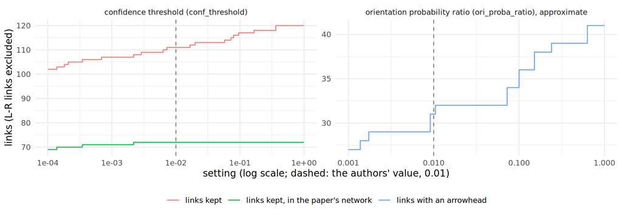

```r
uncut <- run("uncut", conf_threshold = 1e10, ori_proba_ratio = 1)
uncut_links <- retained_links(uncut, small_edges) |> filter(!is_lr)

# Names of the small network -> names of the authors' table (<gene>_<cell type>, one name per gene and cell type)
side_of <- set_names(if_else(small_state$group %in% c("ligands", "senders genes") |
                               str_detect(small_state$var_names, "_senders$"), "Fibroblasts", "DCs"),
                     small_state$var_names)
authors_name <- \(v) paste0(str_remove(v, "_(senders|receivers)$"), "_", side_of[v])
authors_norm <- set_names(paste0(strip(names(authors_mosaic)), "_", col_type), names(authors_mosaic))
paper_links  <- read_tsv(file.path(job_dir, "edgesList.miic.summary.txt"), show_col_types = FALSE) |>
  filter(type == "P") |>
  transmute(link = link_name(authors_norm[x], authors_norm[y])) |>
  pull(link) |> unique()
in_paper <- link_name(authors_name(uncut_links$x), authors_name(uncut_links$y)) %in% paper_links

thresholds <- 10^seq(-4, 0, by = 0.02)
ratios     <- 10^seq(-3, 0, by = 0.02)
arrowhead  <- map_dbl(str_split(uncut_links$proba, ";"), \(p) max(as.numeric(p)))
curves <- bind_rows(
  tibble(panel = "confidence threshold (conf_threshold)", value = thresholds,
         `links kept`                       = map_int(thresholds, \(t) sum(uncut_links$confidence <= t, na.rm = TRUE)),
         `links kept, in the paper's network` = map_int(thresholds, \(t) sum(uncut_links$confidence <= t & in_paper, na.rm = TRUE))),
  tibble(panel = "orientation probability ratio (ori_proba_ratio), approximate", value = ratios,
         `links with an arrowhead` = map_int(ratios, \(r) sum(arrowhead > 1 / (1 + r))))) |>
  pivot_longer(-c(panel, value), names_to = "series", values_to = "links", values_drop_na = TRUE)

ggplot(curves, aes(value, links, colour = series)) +
  geom_step() +
  geom_vline(xintercept = 0.01, linetype = "dashed", colour = "grey50") +
  scale_x_log10() +
  facet_wrap(~panel, scales = "free") +
  labs(x = "setting (log scale; dashed: the authors' value, 0.01)", y = "links (L-R links excluded)", colour = NULL) +
  theme_minimal() +
  theme(legend.position = "bottom")
```

```r
# Checks: the curves at the authors' values against the reference run (cut at 0.01, ratio 0.01)
ref_net <- retained_links(runs[["authors' settings (reference)"]], small_edges) |> filter(!is_lr)
tibble(quantity = c("links kept at conf_threshold = 0.01", "links with an arrowhead at ori_proba_ratio = 0.01",
                    "links with an arrowhead at ori_proba_ratio = 1"),
       curve = c(sum(uncut_links$confidence <= 0.01, na.rm = TRUE), sum(arrowhead > 1 / 1.01), sum(arrowhead > 0.5)),
       run   = c(nrow(ref_net), sum(ref_net$infOrt != 1), sum(uncut_links$infOrt != 1)),
       which_run = c("reference", "reference", "uncut")) |>
  knitr::kable()
```

| quantity | curve | run | which_run |
| --- | --- | --- | --- |
| links kept at conf_threshold = 0.01 | 111 | 111 | reference |
| links with an arrowhead at ori_proba_ratio = 0.01 | 31 | 30 | reference |
| links with an arrowhead at ori_proba_ratio = 1 | 41 | 41 | uncut |

```r
c(paper_links_between_these_variables = sum(map_lgl(str_split(paper_links, " \\| "), \(p)
    all(p %in% authors_name(small_state$var_names)) && p[1] != p[2])))
```

```
paper_links_between_these_variables
                                 77
```

The confidence curve is exact: at 0.01 it gives the 111 links of the reference run. On this small network it has no sharp elbow: about 100 links are kept even at a threshold of 1e-4, and the next ones are added slowly, one by one, up to 120 at a threshold of 1. Of the 77 links of the paper’s network between these variables, 72 are already kept below a threshold of 0.003: the links added above it are not in the paper’s network, consistent with a confidence filter that removes weakly supported links. The orientation curve rises steadily: about 27 links with an arrowhead at a ratio of 0.001, 31 at 0.01 (30 in the reference run, hence “approximate”) and 41 at 1, the `miic()` and server default. Lowering the ratio is a choice of how sure an arrow must be; nothing in the curve singles out one value.

**How to use these curves on your data.** Look for the elbow: the threshold below which the number of links kept falls quickly (strong links only) and above which it rises slowly (links added one by one, each weakly supported). **Do not pick the setting that recovers the most links of a published network**: that reasoning is circular (the published network was itself obtained with one choice of settings), and it would hide the differences you are looking for. Fix the settings first, then compare.

## 8b. Comparing with a run on the web server

The [CausalCCC web server](https://miic.curie.fr/causalCCC.php) runs the same MIIC. Comparing one of its jobs with a local run checks three things at once: that the settings are those you think, that the input is the same table, and that the network is the same. The job is a parameter of this notebook: paste its link (or its 20-character code) when rendering,

```bash
quarto render notebooks/tutorial/causalccc_tutorial.qmd -P server_job:https://miic.curie.fr/...<code>...
```

or, when running the chunks by hand in Positron, set `server_job <- "<link or code>"` in the console after the setup chunk. **Without a job, the chunks of this section are skipped.**

**TipSubmitting a job to compare with**

1. Upload the three files the wrapper wrote for the small network of section 8, in `results/tutorial/small_network/CausalCCC_files/`: `causalCCC_df.csv` (the mosaic table), `causalCCC_st.tsv` (the state order) and `causalCCC_interactEdges.tsv` (the L-R pairs). It runs in a few minutes, on the server and here.
2. In the form, set **confidence cut = yes, number of shuffles = 100, confidence threshold = 0.01, orientation probability ratio = 0.01**, and leave the rest by default (section 8: the form’s defaults are not the authors’ settings). Or keep the defaults on purpose, to see the comparison flag the difference.
3. When the job is finished, copy the link of its result page (or of any of its files) and render with `-P server_job:<link>`.

The authors’ jobs work too: `eaP9Br0llvzxN07zZZEC` (case study 1) and `w0788tM1wzXGHLzNaKKa` (case study 2, already in `data/`; its local run takes 1–3 hours, see below).

### Downloading the job

The files of a job are at `https://miic.curie.fr/server/server_outputs/<code>/<file>`. We keep six of them in `data/<case>/causalccc_server_<code>/` (`case1` for the authors’ case 1 job, `case2` otherwise), skip those already there and log each download in `data/download_log.tsv`, as the download scripts do.

```r
server_code <- server_job_id(server_job)
server_case <- if (server_code == "eaP9Br0llvzxN07zZZEC") "case1" else "case2"
server_dir  <- file.path(root, "data", server_case, paste0("causalccc_server_", server_code))
download_server_job(server_code, server_dir, file.path(root, "data", "download_log.tsv"), root) |>
  knitr::kable()

needed <- c("script.sh", "edgesList.miic.summary.txt", "input.tsv", "clean_state_order.tsv", "clean_interact_edges.tsv")
if (!all(file.exists(file.path(server_dir, needed))))
  stop("Missing files for job ", server_code, ": ", paste(needed[!file.exists(file.path(server_dir, needed))],
       collapse = ", "), ". Is the job finished? Check its page on miic.curie.fr.")
```

### 1. Settings

`script.sh` holds the command the server ran. Each option is translated into the `miic()` argument it sets and compared with the settings of `scripts/run_miic.R` (the authors’ settings, `authors_miic_settings`). An option absent from the command gets the `miic()` default (an absent flag, such as `--orientation`, means `FALSE`).

```r
server_parsed <- parse_server_script(file.path(server_dir, "script.sh"))
settings_table <- compare_settings(server_parsed, authors_miic_settings)
knitr::kable(settings_table)

# Options of the command that this notebook does not translate, as they are written
server_parsed |> filter(!known) |> select(option, written)

settings_differ <- any(settings_table$note == "DIFFERS")
settings_differ
```

### 2. Same input?

The server stores the table it received as `input.tsv`. We compare it with the tables of this tutorial (columns, then values); the closest one comes first.

```r
server_input <- read_tsv(file.path(server_dir, "input.tsv"), guess_max = Inf, show_col_types = FALSE)
local_tables <- list("small network (section 8)"     = small_mosaic,
                     "fibroblasts → DCs (section 6)" = wrapper_out$mosaic_table,
                     "three populations (section 7)" = mosaic3,
                     "authors' input, case study 2"  = authors_mosaic)
imap(local_tables, \(t, name) compare_inputs(server_input, t) |> mutate(local_table = name, .before = 1)) |>
  list_rbind() |>
  arrange(desc(columns_shared / pmax(columns_server, columns_local))) |>
  knitr::kable()
```

### 3. Networks

The local run is `scripts/run_miic.R` on the server’s own three files, so that only MIIC is compared. It is run here for networks of up to 100 variables (a few minutes); for a larger one, the chunk prints the command to run in a terminal (1–3 hours on one thread, about 3 times less with the patched variant on 8 threads), and the comparison appears at the next rendering. If the settings differ (step 1), a second local run uses the server’s settings (saved as a list of `miic()` arguments, which `run_miic.R` accepts as its sixth argument): the difference between the two local runs is the effect of the settings, and the difference between the server and the second local run is the effect of the server.

```r
server_runs_dir <- file.path(results_dir, paste0("server_", server_code))
server_result   <- list(all.edges.summary = read_tsv(file.path(server_dir, "edgesList.miic.summary.txt"),
                                                     show_col_types = FALSE))

local_run <- run_miic_script(root, server_dir, file.path(server_runs_dir, "local_settings"))
local_server_settings_run <- NULL
if (settings_differ) {
  settings_file <- file.path(server_runs_dir, "server_settings.rds")
  dir.create(server_runs_dir, recursive = TRUE, showWarnings = FALSE)
  saveRDS(server_settings_list(server_parsed), settings_file)
  local_server_settings_run <- run_miic_script(root, server_dir, file.path(server_runs_dir, "server_settings"),
                                               settings_file = settings_file)
}

comparisons <- list(
  "server vs local run, our settings"                = list(server_result, local_run),
  "server vs local run, server's settings"           = list(server_result, local_server_settings_run),
  "local runs: our settings vs the server's settings" = list(local_run, local_server_settings_run))
comparisons <- keep(comparisons, \(pair) !is.null(pair[[1]]) && !is.null(pair[[2]]))
if (length(comparisons) == 0) {
  cat("No local run yet: run the command printed above, then render again.\n")
} else {
  imap(comparisons, \(pair, name) compare_miic(pair[[1]], pair[[2]]) |> mutate(comparison = name, .before = 1)) |>
    list_rbind() |>
    mutate(across(where(is.double), \(v) signif(v, 3))) |>
    knitr::kable()
}
```

How to read the verdict (`compare_miic()`, `scripts/benchmarks/compare_outputs.R`, notebook `case2/10`):

- **“identical”**: same retained links, orientations, genuine causations and values. Not possible against the server: its edge list stores the values rounded to 6 decimals.
- **“same decisions, values differ”**: same links, orientations and genuine causations; the best possible verdict against the server. Expect the `confidence` column to differ even with the same settings: the server’s random seed for the permutations is not ours (2026). On our inputs this never changed a decision (checked on the authors’ case study 2 job: same 715 links, 62 confidence values differ, by at most 0.008).
- **“different network”**: look at the settings first (step 1), then at the input (step 2). The links that differ:

```r
reference_run <- local_server_settings_run %||% local_run
if (!is.null(reference_run)) {
  both <- full_join(miic_links(server_result) |> filter(type == "P"), miic_links(reference_run) |> filter(type == "P"),
                    by = "link", suffix = c("_server", "_local"))
  list(only_server  = both |> filter(is.na(type_local)) |> select(link, info_shifted_server, confidence_server),
       only_local   = both |> filter(is.na(type_server)) |> select(link, info_shifted_local, confidence_local),
       orientation  = both |> filter(orientation_server != orientation_local | is_causal_server != is_causal_local) |>
                        select(link, orientation_server, orientation_local, is_causal_server, is_causal_local)) |>
    map(\(t) head(t, 10))
}
```

## 9. Reading the network

The edge list (`all.edges.summary`) has one row per pair of variables examined. The columns that matter:

| Column | Meaning |
| --- | --- |
| `type` | `P` = retained link; `N` = removed |
| `info_shifted` | strength of the link (MI × number of cells, minus the complexity cost) |
| `infOrt` | 1 = not oriented, 2 = x → y, -2 = y → x, 6 = bidirected (latent common cause) |
| `is_causal` | `Y` = **genuine causation**: the arrow is supported by a downstream v-structure, not only by an arrowhead |
| `proba` | arrowhead probabilities, written “x-side;y-side” (the opposite of the documentation) |
| `confidence` | confidence ratio from the permutations (lower = more confident) |

Two artefacts of the `causalccc` branch of `miic`:

- **L-R placeholder rows.** Each L-R pair appears twice: a placeholder (strength 0, `Nxy_ai = 0`) and the imposed link. `retained_links()` drops the placeholders (`Nxy_ai %in% 0`: use `%in%`, not `==`, because of `NA`).
- **L-R strengths are not measured.** Every L-R link gets the strength of the strongest link of the network:

```r
reference <- runs[["authors' settings (reference)"]]
ref_links <- retained_links(reference, small_edges)
ref_links |> filter(is_lr) |> select(x, y, info_shifted)
```

```
# A tibble: 4 × 3
  x      y     info_shifted
  <chr>  <chr>        <dbl>
1 MIF    CD74         2562.
2 MIF    CD44         2562.
3 MIF    CXCR4        2562.
4 CXCL12 CXCR4        2562.
```

```r
max(ref_links$info_shifted[!ref_links$is_lr])
```

```
[1] 2561.709
```

**“Upstream” and “downstream”** in the paper mean the position relative to the L-R link (sender side, receiver side), not a direction found by MIIC: links next to the receptor are often unoriented.

The neighbourhood of the L-R pairs (diamonds), two links deep:

```r
plot_neighbourhood(reference$all.edges.summary |> filter(!(link_name(x, y) %in% ref_links$link[ref_links$is_lr] & Nxy_ai %in% 0)),
                   lr_links = ref_links$link[ref_links$is_lr],
                   centres  = unique(c(small_edges$ligand, small_edges$receptor)),
                   cell_type_of = side_of,
                   label_of = \(v) str_remove(v, "_(senders|receivers)$"),
                   max_distance = 2, title = "Fibroblasts → DCs, around CXCL12/MIF and CXCR4/CD74/CD44")
```

[interactive chart not shown]

The direct neighbours of CXCL12 and CXCR4 (`direction` seen from the centre: `out` = centre → neighbour):

```r
intracellular <- ref_links |> filter(!is_lr)
bind_rows(neighbors_of("CXCL12", intracellular), neighbors_of("CXCR4", intracellular)) |>
  select(node, neighbor, direction, is_causal) |>
  knitr::kable()
```

| node | neighbor | direction | is_causal |
| --- | --- | --- | --- |
| CXCL12 | CXCL14 | none | N |
| CXCL12 | labels_senders | out | N |
| CXCL12 | CFH | none | N |
| CXCL12 | CFD | out | N |
| CXCL12 | IFITM3 | none | N |
| CXCR4 | RGS1 | none | N |
| CXCR4 | NR4A3 | none | N |
| CXCR4 | HLA-B | none | N |

Even on this 51-variable network, CXCL12 is linked to CXCL14, CFH and CFD (oriented CXCL12 → CFD), and CXCR4 to RGS1 and NR4A3: the neighbours the paper names for Figure 3 (notebook `case2/03`).

CXCL12 also points to `labels_senders`, the fibroblast subtype. An arrow from a gene to a metadata variable is not a biological statement: CXCL12 is a marker of a subtype. Metadata that genes cannot cause (condition, patient, batch) can be declared **contextual** in the state order (`is_contextual = 1`), so that MIIC never orients links towards them. The published case studies did not do it (all variables have `is_contextual = 0`).

**How much to trust what.** From the reproduction of case study 2 (notebooks `case2/06` and `case2/07`): with the same cells and slightly different gene selections, links are robust (Jaccard 0.85–0.92 per cell type), orientations of shared links mostly agree (96 %), but genuine causations are not (8 shared of 14 and 12). Read links first, orientations with care, and treat a single genuine causation as a hypothesis.

## 10. Checklist

| Step | Check / setting | Why |
| --- | --- | --- |
| Raw data | integer counts in the `counts` layer; recover them if only log-normalised values exist (known scale factor) | MI is computed on counts |
| Raw data | `JoinLayers()` after Seurat 5 integration; never SCT, scaled or integrated values | the functions read one `counts` layer |
| Raw data | unique gene names, same annotation as the L-R resource | unmatched L-R genes are dropped silently |
| QC | filter empty droplets, damaged cells and doublets **per cell type** before building the table | every cell enters the network |
| QC | detection rate of each L-R gene in its cell type (< 10 % = weak) | MI needs variation |
| Populations | enough cells (hundreds), and metadata (condition, subtype, possibly binned library size) for pooled data | confounders create links |
| L-R pairs | one table per sender → receiver direction; check the order (cap of 8) | the wrapper handles one direction |
| Selection | `n_genes` from the MI curves and the network size you can afford (~25 per run here) | size and run time |
| Selection | more than 8 ligands or receptors: call `causalCCC.MIselection()` directly | the wrapper drops the extra ones silently |
| Selection | remove the metadata from the selected genes; patch the wrapper with two metadata or more | a metadata column can be selected as a gene |
| Selection | remove ribosomal / mitochondrial genes from the candidates if they dominate the MI ranking | they follow library size |
| Selection | keep the MI tables (`save = TRUE`) and redo the selection with `select_genes()` | seconds instead of hours |
| Selection | compute the MI tables with `compute_mi_table()`, blocks of about 100 genes | same table, faster, a third of the memory |
| Mosaic | several directions: pool per cell type, name `<gene>_<cell type>`, check for duplicated columns | duplicates make contradictory orientations |
| Mosaic | discrete rule “≤ 5 values counting `NA`”; `set.seed()` before building | same rules as the package, reproducible order |
| MIIC | `interact_edges` with columns `ligand`, `receptor`; `n_threads = 1`, or 8 with the patched variant | late failure; crashes |
| MIIC | no identical columns (`duplicated_columns()`) | duplicates double links and destabilise orientations |
| MIIC | check `result$params`: invalid values (`cplx = "bic"`) are replaced by the defaults | silent change of settings |
| MIIC | metadata that genes cannot cause: `is_contextual = 1` | no arrows towards condition or batch |
| MIIC | state the settings: `ori_proba_ratio`, `n_shuffles`, `conf_threshold` (authors: 0.01, 100, 0.01) | they change orientations and the number of links |
| Web server | set confidence cut = yes, 100 shuffles, threshold 0.01, orientation probability ratio 0.01; compare the job with a local run (section 8b) | the form’s defaults are not the authors’ settings |
| Reading | drop L-R placeholder rows; ignore L-R strengths | artefacts of the `causalccc` branch |
| Reading | trust links > orientations > genuine causations | robustness measured in case study 2 |